# How to use the AndersR package

Anders Jensen

2026-03-25

# Introduction

This file is a detailed tutorial on how to best utilise the AndersR package for proteomics analysis. It will go through each step of the pipeline and explain how the different functions work.

If you are having issues with any of the functions or something isn’t working then dont hesitate to contact me and I will be happy to help (hlajens2@liverpool.ac.uk).

The package was designed as a way to make proteomics analysis as simple and accessible as possible, whilst still maintaining the robustness needed for correct analysis.

# How to install AndersR

The full R package is available on github so installation is relatively straightforward with the **devtools** package.

Make sure that you have devtools installed and then run the following code.

```r
devtools::install_github("AJensen14/AndersR")
library(AndersR)
```

# Functions

Below is a list of functions with a brief explanation of what they are trying to do.

| Function Name | Description |
| --- | --- |
| Add_Grouping | Add group information to the column names |
| Boxplot_Proteins | Make a boxplot for a specific protein |
| Check_Data | Calculates %missing values across samples |
| Check_Filtering | Looks at the effect of different filtering cut-offs |
| Differential_Abundance_Analysis | Calculates differential abunance of proteins |
| Dummy_Data | Generates a dummy dataset for practice |
| Filter_Proteins | Filters proteins based on %missing |
| Gene_To_Protein | Converts gene names to protein names |
| GO_from_DA | Takes a differantial abundance result and runs through clusterprofiler |
| GO_from_DA_all | Completes all possible clusterprofiler analysis (MF, CC, BP) |

[output cut: 10 more lines]

I tried my best to name the functions as best as I could so they explain exactly what they are doing in the name.

Each function has its own roxygen skeleton so once you have installed and loaded the package you can run ?function and more of a description will pop up in the help window.

# Getting your data ready

So the biggest hurdle with the AndersR package is making sure your starting data is suitable to be used.

The best way to do this is to have your genes/protein/accession as the rownames and your samples as the column names.

To ensure that your data is in the correct format you can use the **Dummy_Data** function to generate a working dataset and compare with your own dataset.

```r
# load package
library(AndersR)

# generate dummy data
df <- Dummy_Data(n_proteins = 1000,
                 group1 = "old",
                 group2 = "young",
                 n_replicates = 5)

# see how it looks
head(df)
```

```
##                old_1      old_2      old_3      old_4      old_5    young_1
## Protein_1  318990594  355755008  290448983  232280042  286070271  221741983
## Protein_2  289689045  609888782  247780636  563521694  384487133  518427044
## Protein_3 3263550187         NA 2460145118 2003270872 2405149013 1594061573
## Protein_4         NA  586750350  496401756  432371373  364862158         NA
## Protein_5  433478124  540585377  675419068  452114439  659529240  487430530
## Protein_6 2740567796 3229111762 5072159838 2073788985 4079626436 2480020603
##              young_2    young_3    young_4    young_5
## Protein_1  234405925  168949855  652429739         NA
## Protein_2  371763316  450631525         NA  420828498
## Protein_3 3855158999 2581903032 1674667576 2500520782
## Protein_4  461328080  591457031  446930182  563219543
## Protein_5         NA         NA  533993763  504253120
## Protein_6 2993485582 2667638322 2154550212 2822273878
```

If you are using spectronaut then you can use the **Tidy_Spectronaut** function, which will read in the output file and wrangle the data so it is suitable. I only added this function because this is what I use most commonly. I used to have a progenesis function but it got lost somewhere.

```r
df <- Tidy_Spectronaut(file_path = "path/to/your/file/data.tsv")
```

# Standard workflow

Okay so for this section I am going to go through exactly how to use the package.

As a reminder this package was built to do this in the simplest possible way and anyone telling me “this could be optimised”, “this is slow” or “you can do this way quicker” can respectfully leave me alone.

For each step of the workflow I will put the header as the function I am discussing.

I will use the **Dummy_Data** function to work through the backbone of the package.

## Load_Packages

To begin with to use this package you are going to need a lot of other RPackages. Specifically these ones:

- usethis
- dplyr
- ggplot2
- reshape2
- readr
- tibble
- stringr
- cowplot
- NormalyzerDE
- SummarisedExperiment
- tidyverse
- rstatix
- ggpubr
- ggrepel
- limma
- scales
- colorspace
- clusterProfiler
- org.Hs.eg.db

Originally when making this I tried to code it so that these packages are installed with my package but this didn’t go so well and I found it easier to install them separately. The packages only need to be installed once and then using the **Load_Packages** function will load them for you.

If you are struggling to install these packages then try the following code:

```r
pkgs <- c("usethis", "dplyr", "ggplot2", "reshape2", "readr", "tibble", "stringr",
          "cowplot", "NormalyzerDE", "SummarizedExperiment", "tidyverse", "rstatix",
          "ggpubr", "ggrepel", "limma", "scales", "colorspace", "clusterProfiler","org.Hs.eg.db")

installed <- rownames(installed.packages())

for (p in pkgs) {
  if (!p %in% installed) {
    if (p %in% c("clusterProfiler", "org.Hs.eg.db", "SummarizedExperiment", "NormalyzerDE", "limma")) {
      if (!requireNamespace("BiocManager", quietly = TRUE))
        install.packages("BiocManager")
      BiocManager::install(p, update = FALSE, ask = FALSE)
    } else {
    install.packages(p)
    }
  }
}
```

If that still doesn’t work, let me know.

To use the **Load_Packages** function simply run the following code:

```r
Load_Packages()
```

## Dummy_Data

This function will generate some example data that works with the rest of the workflow.

There are five arguments that allow for custom example data that may suit your needs.

1. n_proteins - Number of proteins
2. group1 - The name of group 1
3. group2 - The name of group 2
4. n_replicates - How many replicates of each group
5. missing_frac - % of missing values

The example I will use will have 1500 proteins, old vs young, n = 5, with 20% of the data being missing

```r
set.seed(27)

df <- Dummy_Data(n_proteins = 1500,
                 group1 = "old",
                 group2 = "young",
                 n_replicates = 5,
                 missing_frac = 0.2)

head(df)
```

```
##                old_1      old_2      old_3      old_4      old_5    young_1
## Protein_1         NA         NA  188252832         NA  304629519  374391121
## Protein_2  444490944  365628387  271508114  437387087  435744486  428856503
## Protein_3         NA 2513042157 2739532864 1904956962 2440602698 2309855809
## Protein_4  443686136  621552162  453126597  353089059  350434922         NA
## Protein_5  341560621         NA  624936982  669311219  302903470         NA
## Protein_6 2691379361 2183662816 3844692528 2536784708 1815486607 3121484124
##              young_2    young_3    young_4    young_5
## Protein_1  273565328  329540749  340055481  166177135
## Protein_2  362033154  265803548  439546122  478503694
## Protein_3 2501618869         NA 1275117008 2388559403
## Protein_4         NA  379252180  392320154 1228922787
## Protein_5  556718352  313964500  471055079  603648910
## Protein_6 3070593310 1807789340         NA 3437287238
```

This data should look very similar to an example proteomics dataset. We can confirm this by looking at the distribution of the data from this.

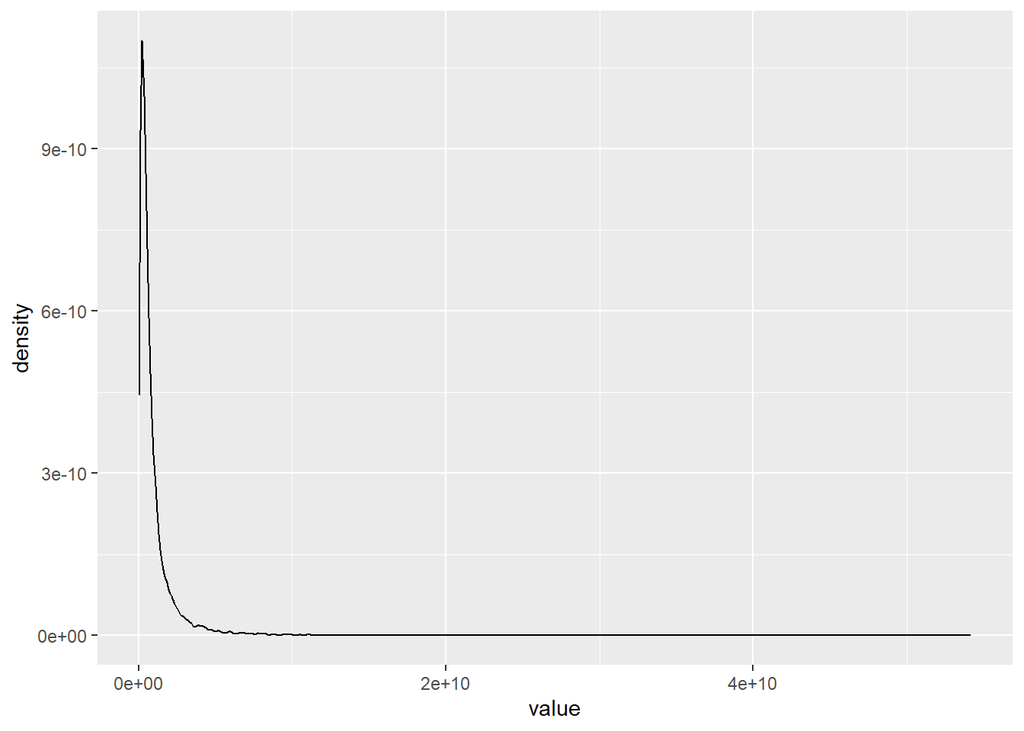

## Tidy_Column_Names/Add_Grouping

These two functions can sort of go together really. They are the part of this whole pipeline some people will hate if they have experience doing proteomics data analysis.

So basically the way they work is you input the dataset you have and then each column (sample) will appear in the console (bottom of the page) and you will have to write the new column name for that sample.

The reason I chose to do it like this is that from my experience the sample names can be long and confusing, this way you can sort of manually edit them.

So yeah both of these functions do the same thing I guess but I use them both to keep things simple.

For example I would use **Tidy_Column_Names** to change a name to sample_1, sample_2, sample_3 etc….

And would then use **Add_Grouping** to change to sample_1_old, sample_2_young, sample_3_old etc….

Really straightforward just type what you want for each column name in the console

**IMPORTANT - CHECK YOUR SPELLING**

## Check_Data

This is a really important function and one of the first things I look at when analysing someones proteomics data.

Basically what this function does is it goes through each sample and works out the number of missing values, as well as giving you a percentage of missing data as an overall dataset. Too many times have I seen people look into % missing across an entire dataset, the beauty of this is that it shows samples individually so you can highlight dodgy samples.

This function has five arguments:

1. data - The dataframe
2. group_patterns - A vector of the group labels (c(“old”, “young”))
3. group_labels - A vector if you want to change the label names
4. fill_colours - Colours you want to use
5. summary_colours - Again more colour customisation

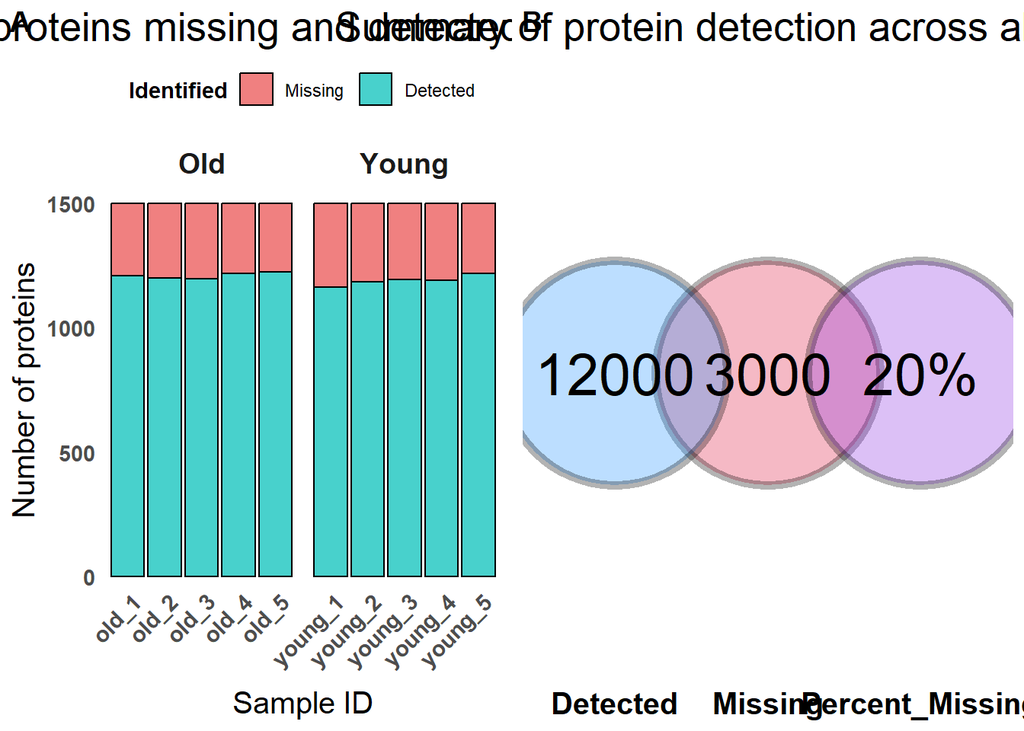

```r
Check_Data(data = df,
           group_patterns = c("old", "young"))
```

So as anticipated we have 20% missing values in total and none of my samples stand out. I wish it was always like this.

## Make_Matrix

A similar function to Tidy_Column_Names and Add_Grouping.

This function will go through each column and ask for the grouping information to make a sample matrix.

Whenever i’ve taught people how to do proteomics analysis I always get asked about what a sample matrix means so this is why the function is made like this.

So if I had a sample called “old_1” my input would be “old”.

Remember to save the matrix to your environment:

```r
matrix <- Make_Matrix(data = df)

head(matrix) #see structure

table(matrix$group) # also good to see how many of each group you have
```

```
##    sample group
## 1   old_1   old
## 2   old_2   old
## 3   old_3   old
## 4   old_4   old
## 5   old_5   old
## 6 young_1 young
```

```
##
##   old young
##     5     5
```

## Check_Filtering/Filter_Proteins

I love these functions, and again this solves one of the biggest problems I see in proteomics data analysis.

Normally when filtering out proteins you have the option to filter out proteins based on them being in a certain percentage of samples, but I think this is missing important details.

Say you have five samples from one group and five samples from another group and then only want proteins found in atleast 50% of samples. You may be keeping proteins only found in one group. Any statistics you do with this protein is absolutely meaninless. You dont need a statistical test to say that a number is bigger than zero.

A better way to do this is to say, whats the minimum number of samples per group, my protein needs to be present in.

So using the example above, I would say I only want proteins in at least 3/5 young and 3/5 old replicates. This is good becuase these are the only ones worth comparing quantitatively. Proteins not found in one group are still interestingly but should be analysed upstream.

The **Check_Filtering** function will visualise the effects of different filtering stringency and the **Filter_Proteins** will carry out the job.

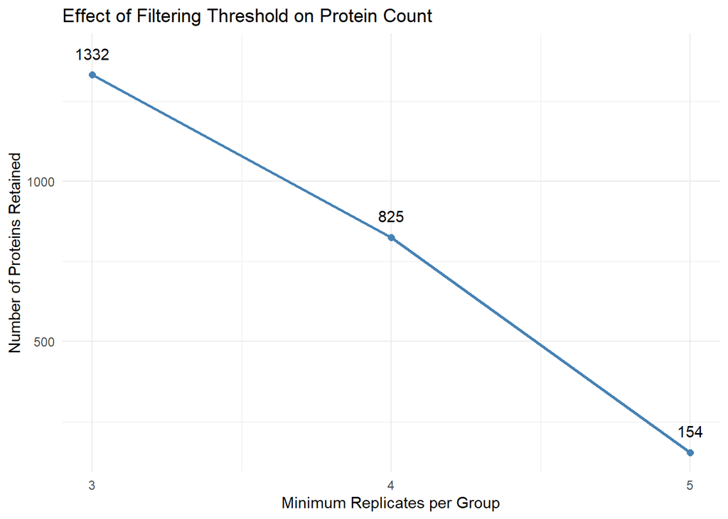

```r
# Check filtering effects
Check_Filtering(data = df, matrix = matrix, n_samples = 5)
```

```r
# Carry out the filtering
filtered_df <- Filter_Proteins(data = df, matrix = matrix, min_samples = 3)
nrow(filtered_df)
```

```
## [1] 1332
```

So the min_samples argument of the **Filter_Proteins** functions specifies how many samples per group a protein needs to be in.

## Test_Normalisation/Normalise_Data

After we have filtered proteins we now need to normalise our dataset.

This section is a bit confusing so if you don’t like it thats completely fine.

If you want to take the time to understand it, I would recommend reading the source code for the function to see exactly what it does.

If I had to sum it up in one sentence - “It takes multiple different commonly used proteomics normalisation strategies and gives you measures to suggests which is best”

Data is normalised in four ways

1. Median
2. Quantile
3. Log2
4. VSN

Then the following metrics are produced

1. Coefficient of variation - Variability of replicates within groups
2. Density plot - Distribution of intensities
3. PCA plot - Sample clustering
4. MA plot - log-fold change vs average intensity (Should be centered at 0)
5. RLE plot - relative log expression

**IMPORTANT - DON’T TAKE THIS AS 100% QUANTITATIVE THERE IS SKILL IN LOOKING AT THESE OUTPUTS AND INTERPRETING**

Theres actually no correct answer for this, but in my opinion saying you have done this is much better than not doing it. During my time analysing datasets I have used this function and cancelled out each of these normalisation methods and also used them all. Eventually I will do a project that understands what determines which is the best but that is not simply a mathematical question.

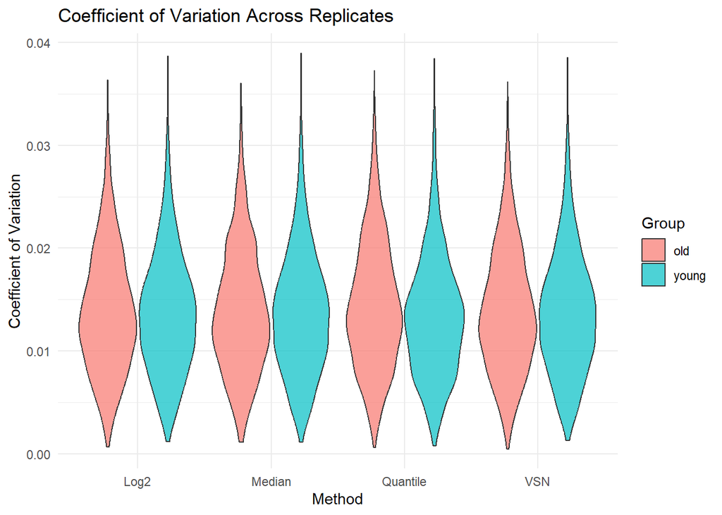

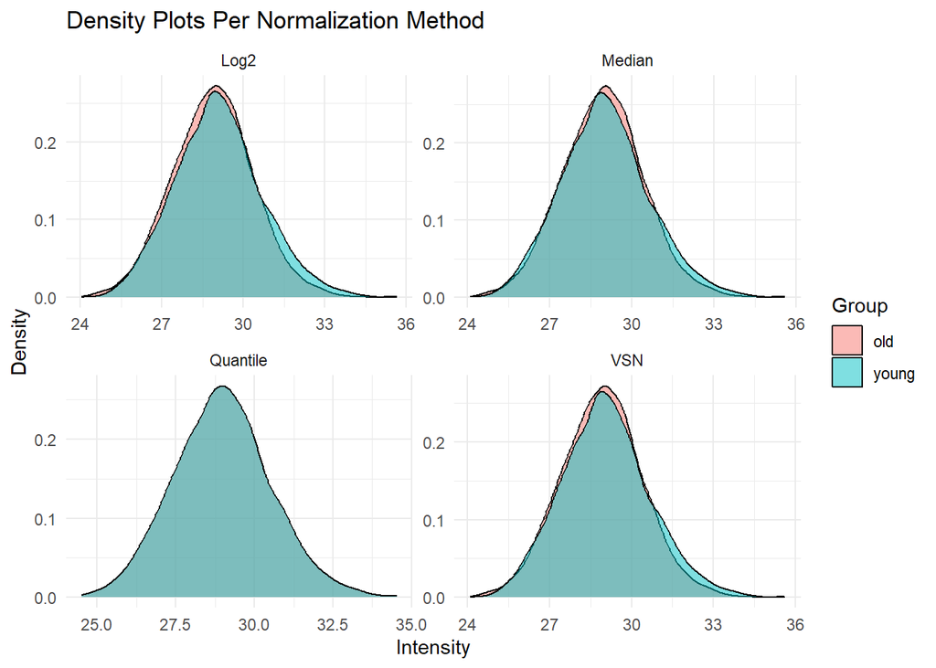

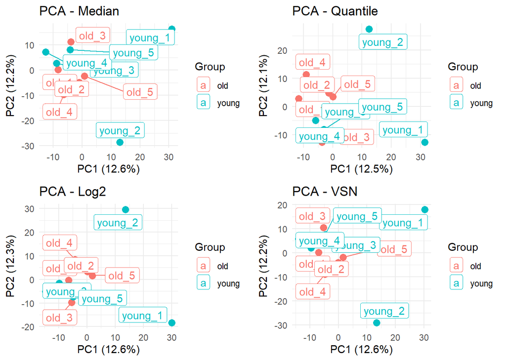

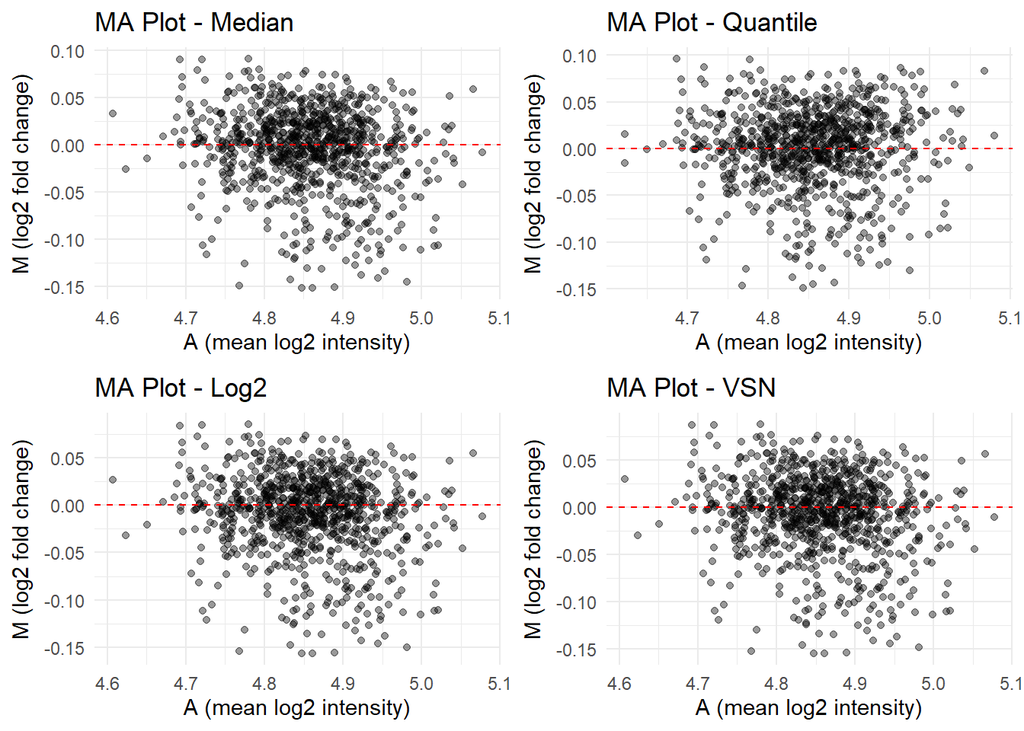

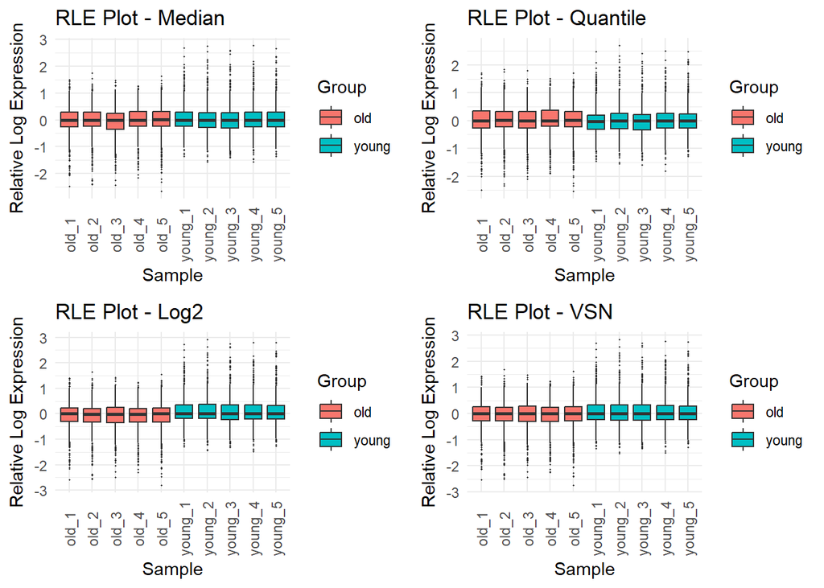

```r
Test_Normalisation(filtered_df = filtered_df, sample_matrix = matrix)
```

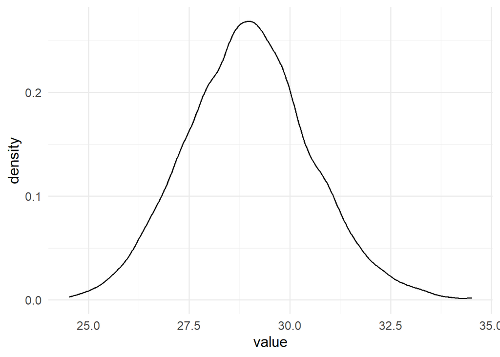

```r
# Normalise
df_normalised <- Normalise_Data(filtered_df = filtered_df, method = "Quantile")

# Prove it is normalised
df_normalised %>%
  melt() %>%
  ggplot(aes(x = value))+
  geom_density()+
  theme_minimal(base_size = 15)
```

## Differential_Abundance_Analysis

Okay so you have done all the hard/boring parts and now the final step is to work out which proteins are changing between your biological conditions.

The function uses the limma models so if you want to learn more about limma I would suggest reading [this paper](https://pmc.ncbi.nlm.nih.gov/articles/PMC4402510/).

To use the function the only challenging part is understand which way round the write the contrast_formula argument.

From this you are going to get log(fold-change) values, the order you write the contrast_formula effects which way round they go:

**contrast_formula = c(“old - young”)** - Proteins with a **positive** fold change are higher in old **contrast_formula = c(“young - old”)** - Proteins with a **negative** fold change are higher in old

There are different methods to adjust p-values to account for multiple testing (“None”, “BH”, “BY”, “holm”, “hochberg”, “hommel”, “bonferroni”)

```r
results <- Differential_Abundance_Analysis(normalised_data = df_normalised,
                                           sample_matrix = matrix,
                                           contrast_formula = c("old - young"),
                                           adjust.method = "BH")
head(results)
```

```
##                  logFC  AveExpr         t      P.Value    adj.P.Val        B
## Protein_23   -2.240320 28.28103 -8.114068 7.685077e-14 6.097284e-11 20.98528
## Protein_811  -2.659428 26.17356 -8.096520 9.155081e-14 6.097284e-11 20.77180
## Protein_1331 -2.069938 28.73024 -7.629866 1.358525e-12 5.652841e-10 18.20112
## Protein_1107 -2.083419 28.46704 -7.561379 2.025862e-12 5.652841e-10 17.81406
## Protein_750  -2.062189 30.40659 -7.553419 2.121937e-12 5.652841e-10 17.76918
## Protein_458  -2.338422 29.07354 -7.453598 3.922054e-12 8.390453e-10 17.17409
```

## Summarise_DA

This is a nice function that gathers all the significant proteins into a useful list and is also needed for later functions involving clusterprofiler.

All you need to do is input the differential abundance results, the logFC cutoff and the p value cutoff.

```r
summary_result <- Summarise_DA(result = results, logFC_threshold = 0.58, p_value_threshold = 0.05)
```

```
## [1] "In total there were 265 significant proteins (p < 0.05) Following p-value adjustment there are 158 significant proteins."
## [1] "Proteins can be accessed inside the list that is produced with this function"
```

## Boxplot_Protein/PCA_Plot/Volcano_Plot

All do exactly what they say on the tin. Simple plotting functions that produce ggplot objects.

The volcano plot has an additional feature where raw p-values are plotted but proteins significant after adjustment are labelled in bold.

If you dont like the way the data is plotted, it is really difficult to make plotting functions that everyone likes, I would recommend reading my ggplot2 handbooks to be able to plot them yourself.

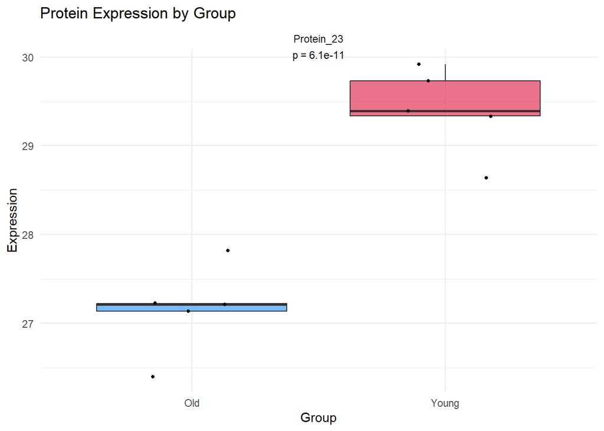

```
##       Protein  Sample Expression group
## 1  Protein_23   old_1   27.81866   old
## 2  Protein_23   old_2   27.21668   old
## 3  Protein_23   old_3   27.13972   old
## 4  Protein_23   old_4   26.40357   old
## 5  Protein_23   old_5   27.22573   old
## 6  Protein_23 young_1   28.63371 young
## 7  Protein_23 young_2   29.33444 young
## 8  Protein_23 young_3   29.39312 young
## 9  Protein_23 young_4   29.72811 young
## 10 Protein_23 young_5   29.91656 young
```

```r
# Boxplots (can make more than one at the same time)
Boxplot_Proteins(data = df_normalised, DA_result = results, matrix = matrix,
                 proteins = c("Protein_23"),
                 group1 = "old", group2 = "young", p_type = "adj")
```

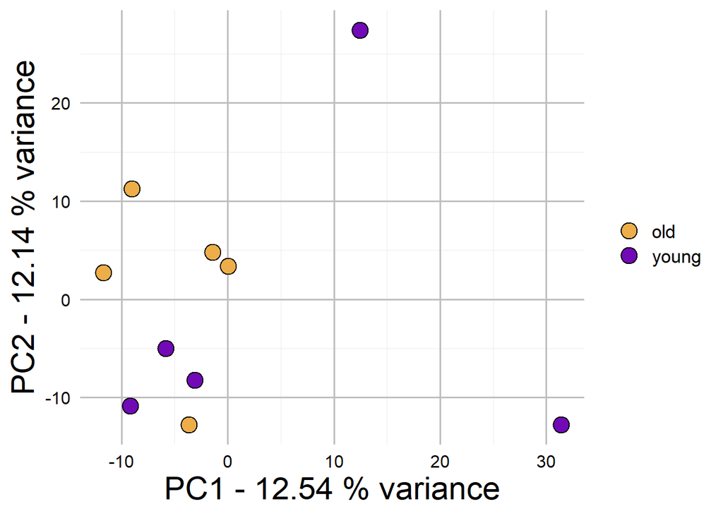

```r
# PCA plot
Plot_PCA(normalised_df = df_normalised, matrix = matrix, labels = c("old", "young"))
```

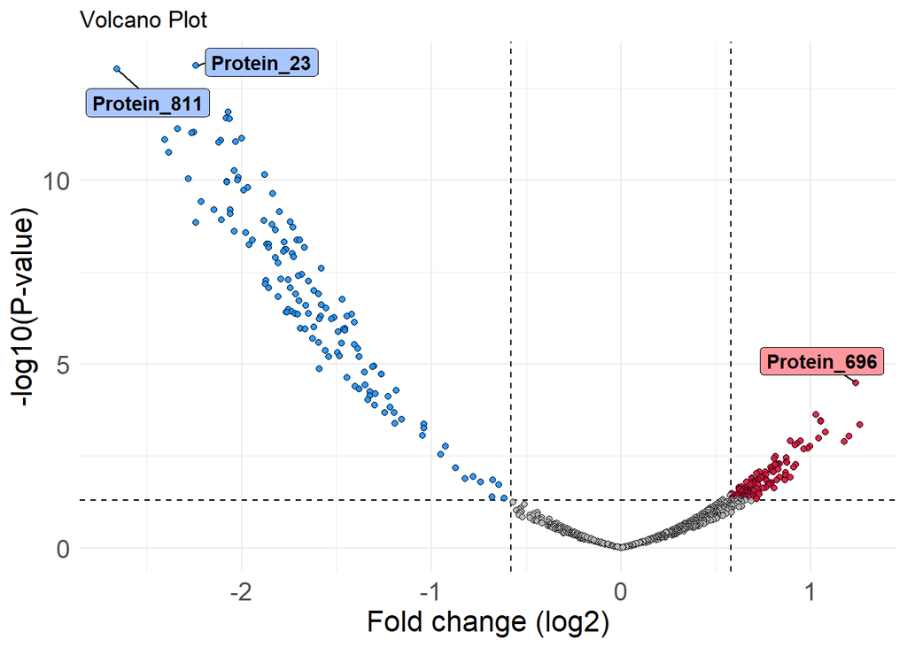

```r
# Volcano plot
Volcano_Plot(daa_result = results, pval_threshold = 0.05, logFC_threshold = 0.58)
```

## Make_IPA

We use Qiagen IPA a lot as a lab group and to use that you need to make an IPA suitable file.

That means you have your calculated results but as well as this include any proteins that were previsouly filtered out and giving them a p value of 1 and a log fold change of 0.

This function does just that

```r
df_IPA <- Make_IPA(de_file = "differential_abundance_results.csv",
                   tsv_file = "raw_data_results.tsv")
```

## GO_from_DA/GO_from_DA_all

These are functions that take your differential abundance results and input them into clusterprofiler to determine the “molecular function”, “biological processes” and “cellular component” of your protein lists. It does this by inputting your data seperately depending on the logFC.

The **GO_from_DA_all** function was simply made to do everything in one go.

```r
GO_from_DA(DA_summary = summary_result,
           ontology = "BP", # CC, BP or MF
           use_adj_p = T, # T for Adj or F for raw
           group_up = "old", # group +ve
           group_down = "young", # group -ve
           top_n = 15) # how many GO terms for the plot
```

# Conclusion

I hope this helps when using the AndersR package. If it even helps one person then I will be happy.

Protoemics analysis is not easy and with more and more people blindly trusting AI it’s important to have reasons to do different stages of analysis.

It’s a bit of a black box out there in terms of analysis so I hope this manages to simplify and explain my approach.

If you need any more assistance with R, proteomics, coding or specifically this package email me (hlajens2@liverpool.ac.uk). Or you can visit [my website](https://ajensen14.github.io/) for more tutorials and information.